# Working with genomic range data in R

Biodiversity Informatics (BIOL 475/575)

February 22, 2022

Programmer: Jenna

In this program, we struggled. Then we began working with Genomic ranges. This included creating ranges (using start, end, width, range), plotting ranges, reading the data we created, merging ranges, and then working with more advanced operations. This included dealing with buffers, removing buffers, as well as, identifying overlapping sequences and identifying the gaps. It was fun!

### Header

```r
# Load Libraries
library(ezknitr)
library(ggplot2)

# Clear Environment & Set Seed
remove(list=ls())
set.seed(71587)
```

## 1. Load libraries from new sources

### Use biocManager to get package GenomicRanges

```r
# if (!require("BiocManager", quietly = TRUE))
#   install.packages("BiocManager")
# BiocManager::install(version = "3.14")
```

Now install the package

```r
# BiocManager::install("GenomicRanges")
library(IRanges)
```

Source the script from the textbook to make figures

```r
source("plot-ranges.R")
```

## 2. Introduction to range data

IRanges are an object that R recognizes as being a genomic range.

Remember that ranges would normally have metadata such as

1. Chromosome name, such as “chr17” or “chrY” or “contig184”
2. Range that demonstrates the specific sequence on the chromosome
3. Strand, which is either forward (positive) or backward (negative)

```r
# Ranges can be made by designating start and end

(rng <- IRanges(start = 4, end = 13))
```

```
## IRanges object with 1 range and 0 metadata columns:
##           start       end     width
##       <integer> <integer> <integer>
##   [1]         4        13        10
```

```r
# Ranges can be made by designating start or end AND width

(rng <- IRanges(start = 4, width = 11))
```

```
## IRanges object with 1 range and 0 metadata columns:
##           start       end     width
##       <integer> <integer> <integer>
##   [1]         4        14        11
```

IRanges objects can also be created to contain many ranges

```r
(x <- IRanges(start = c(4, 7, 2, 20),
              end = c(13, 7, 5, 23)))
```

```
## IRanges object with 4 ranges and 0 metadata columns:
##           start       end     width
##       <integer> <integer> <integer>
##   [1]         4        13        10
##   [2]         7         7         1
##   [3]         2         5         4
##   [4]        20        23         4
```

And each range within the IRanges object can be named:

```r
names(x) <- letters[1:length(x)]
x
```

```
## IRanges object with 4 ranges and 0 metadata columns:
##         start       end     width
##     <integer> <integer> <integer>
##   a         4        13        10
##   b         7         7         1
##   c         2         5         4
##   d        20        23         4
```

Let's plot the ranges

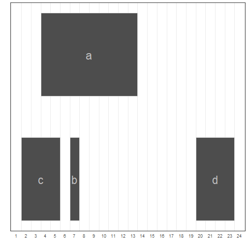

```r
plotIRanges(x)
```

What values start each range?

```r
start(x)
```

```
## [1]  4  7  2 20
```

What values end each range?

```r
end(x)
```

```
## [1] 13  7  5 23
```

What is the width of each range?

```r
width(x) #individual width of each read
```

```
## [1] 10  1  4  4
```

What is the total range of the IRanges object?

```r
range(x) #summary of all reads from start to end
```

```
## IRanges object with 1 range and 0 metadata columns:
##           start       end     width
##       <integer> <integer> <integer>
##   [1]         2        23        22
```

What is the difference between range(x) and width(x)??

> Range summarizes the start and end and width across all the reads/ranges, but width gives just each individual range's width We can manipulate the ranges with standard arithmetic:

```r
end(x) <- end(x) + 4
x
```

```
## IRanges object with 4 ranges and 0 metadata columns:
##         start       end     width
##     <integer> <integer> <integer>
##   a         4        17        14
##   b         7        11         5
##   c         2         9         8
##   d        20        27         8
```

We can also use many of the other R functions to manipulate IRanges:

Use subsetting to look at just second and third row of x

```r
x[2:3]
```

```
## IRanges object with 2 ranges and 0 metadata columns:
##         start       end     width
##     <integer> <integer> <integer>
##   b         7        11         5
##   c         2         9         8
```

```r
x[c(1,3)] #for rows that are not consecutive
```

```
## IRanges object with 2 ranges and 0 metadata columns:
##         start       end     width
##     <integer> <integer> <integer>
##   a         4        17        14
##   c         2         9         8
```

Use subsetting to look at just ranges named “a” and “c”

```r
x[c("a","c")]
```

```
## IRanges object with 2 ranges and 0 metadata columns:
##         start       end     width
##     <integer> <integer> <integer>
##   a         4        17        14
##   c         2         9         8
```

Display logical answer for when start of x is less than 5

```r
x[start(x) < 5]
```

```
## IRanges object with 2 ranges and 0 metadata columns:
##         start       end     width
##     <integer> <integer> <integer>
##   a         4        17        14
##   c         2         9         8
```

Display ranges that are greater than 8 in width

```r
x[width(x) > 8]
```

```
## IRanges object with 1 range and 0 metadata columns:
##         start       end     width
##     <integer> <integer> <integer>
##   a         4        17        14
```

We can also merge ranges together with c()

```r
(a <- IRanges(start = 7, width = 4))
```

```
## IRanges object with 1 range and 0 metadata columns:
##           start       end     width
##       <integer> <integer> <integer>
##   [1]         7        10         4
```

```r
(b <- IRanges(start = 2, width = 5))
```

```
## IRanges object with 1 range and 0 metadata columns:
##           start       end     width
##       <integer> <integer> <integer>
##   [1]         2         6         5
```

```r
c(a,b) #merged
```

```
## IRanges object with 2 ranges and 0 metadata columns:
##           start       end     width
##       <integer> <integer> <integer>
##   [1]         7        10         4
##   [2]         2         6         5
```

## 3. More advanced range operations

```r
x <- IRanges(start = c(40, 80),
             end = c(67, 114))
names(x) <- letters[1:length(x)]
x
```

```
## IRanges object with 2 ranges and 0 metadata columns:
##         start       end     width
##     <integer> <integer> <integer>
##   a        40        67        28
##   b        80       114        35
```

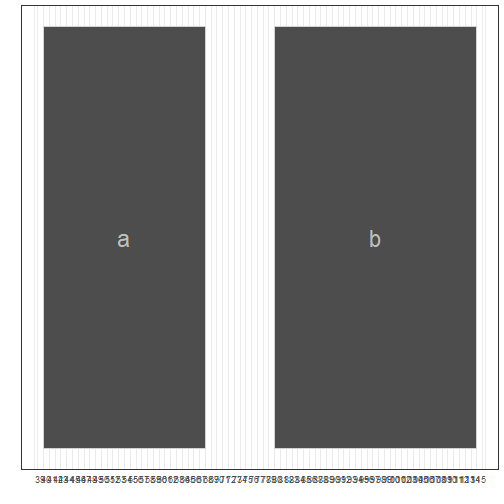

```r
plotIRanges(x)
```

By adding 4L, this grows the sequence symmetrically by 4 on each side

```r
(y <- x + 4L)
```

```
## IRanges object with 2 ranges and 0 metadata columns:
##         start       end     width
##     <integer> <integer> <integer>
##   a        36        71        36
##   b        76       118        43
```

```r
names(y) <- paste0(names(y), "+ 4L")
y
```

```
## IRanges object with 2 ranges and 0 metadata columns:
##             start       end     width
##         <integer> <integer> <integer>
##   a+ 4L        36        71        36
##   b+ 4L        76       118        43
```

By subtracting, we symmetrically cut off each end of the sequence

```r
z <- x - 10L
names(z) <- paste0(names(z), "- 10L")
z
```

```
## IRanges object with 2 ranges and 0 metadata columns:
##              start       end     width
##          <integer> <integer> <integer>
##   a- 10L        50        57         8
##   b- 10L        90       104        15
```

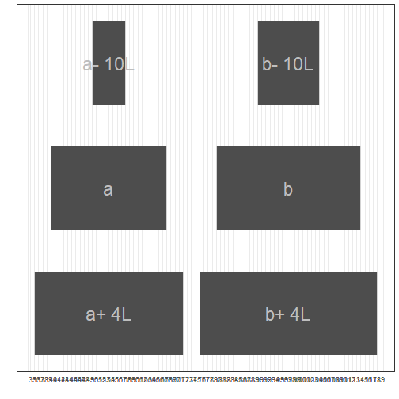

```r
plotIRanges(c(x, y, z))
```

By restricting the ranges, we cut them off to fit in a specific range

```r
y <- IRanges(start = c(4, 6, 10, 12), width = 13)
names(y) <- letters[1:length(y)]

z <- restrict(x = y, start = 5, end = 10)
names(z) <- paste0(names(z), "-restricted")

c(y,z)
```

```
## IRanges object with 7 ranges and 0 metadata columns:
##                    start       end     width
##                <integer> <integer> <integer>
##              a         4        16        13
##              b         6        18        13
##              c        10        22        13
##              d        12        24        13
##   a-restricted         5        10         6
##   b-restricted         6        10         5
##   c-restricted        10        10         1
```

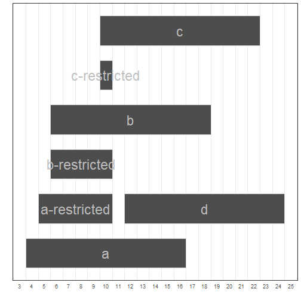

```r
plotIRanges(c(y, z))
```

We can also flank the ranges to create downstream or upstream sequences that contain promoter sequences

```r
x <- IRanges(start = c(40, 80),
             width = c(28, 35))
names(x) <- letters[1:length(x)]
x
```

```
## IRanges object with 2 ranges and 0 metadata columns:
##         start       end     width
##     <integer> <integer> <integer>
##   a        40        67        28
##   b        80       114        35
```

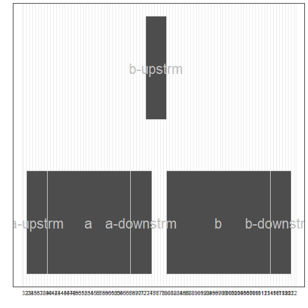

```r
# Upstream Flank
y <- flank(x, width = 7, start = T)
names(y) <- paste0(names(y), "-upstrm")

# Downstream Flank

z <- flank(x, width = 7, start = F)
names(z) <- paste0(names(z), "-downstrm")

plotIRanges(c(x, y, z))
```

We can also reduce the ranges that are potentially overlapping by merging them to a single range in the result. This is useful if we care about what regions a sequence covers, but not the specific ranges

```r
set.seed(0) # reset random generator, make sure we all have the same result
# Create a longer set of ranges, 20 total

alns <- IRanges(start = sample(seq_len(50), 20),
                width = 5)
length(alns)
```

```
## [1] 20
```

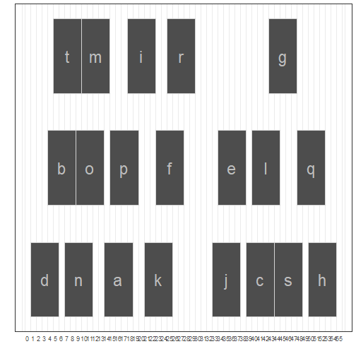

```r
names(alns) <- letters[1:length(alns)]

plotIRanges(alns)
```

```r
alns.reduce <- reduce(alns)
names(alns.reduce) <- paste0(letters[1:length(alns.reduce)], "-reduce")
alns.reduce
```

```
## IRanges object with 2 ranges and 0 metadata columns:
##                start       end     width
##            <integer> <integer> <integer>
##   a-reduce         1        29        29
##   b-reduce        33        54        22
```

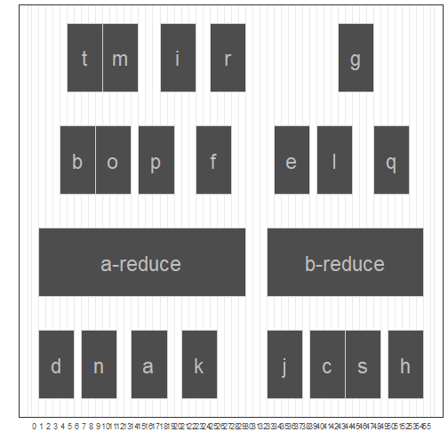

```r
plotIRanges(c(alns, alns.reduce))
```

Similarly, we can identify the gaps!

```r
alns.gap <- gaps(alns)
names(alns.gap) <- paste0(letters[1:length(alns.gap)], "-gap")
alns.gap
```

```
## IRanges object with 1 range and 0 metadata columns:
##             start       end     width
##         <integer> <integer> <integer>
##   a-gap        30        32         3
```

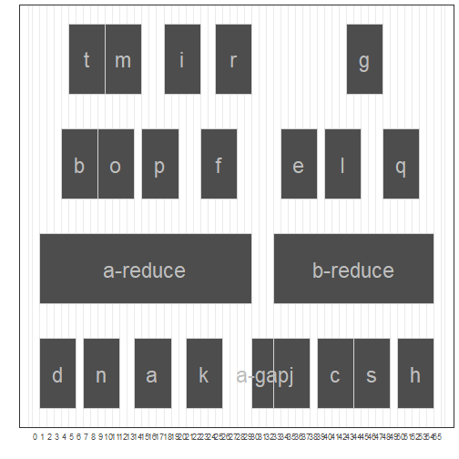

```r
plotIRanges(c(alns, alns.reduce, alns.gap))
```

### Footer

spin this with: ezspin(file = “Jenna/programs/20220223_range_data.R”,out_dir = “Jenna/output”, fig_dir = “figures20220223”,keep_md = FALSE, keep_rmd = FALSE)